# SolutionsForHomework2

## Mathematics in the Real World

### Solutions for Homework 2

#### Prof. Jack Poulson; May 1, 2015

#### Problem 1

**One step:** The two possible endpoints are:

- -1, which can occur $\binom{1}{1}=1$ way, with probability $\frac{1}{2}$ for this event
- +1, which can occur $\binom{1}{0}=1$ way, with probability $\frac{1}{2}$ for this event

The expectation is

$$ E[W_1] = \frac{1}{2}*(-1) + \frac{1}{2}*(+1) = 0, $$

and the variance is

$$ \text{Var}[W_1] = E[(W_1-E[W_1])^2] = \frac{1}{2}*(-1-0)^2 + \frac{1}{2}*(+1-0)^2 = 1. $$

**Two steps:** The three possible endpoints arise from the different number of total forward/backward steps:

- 2 total backward steps ends at -2, which can happen $\binom{2}{2}=1$ way, and this path has probability $(\frac{1}{2})^2=\frac{1}{4}$, and so the walk ends at $-2$ with probability $$ P[W_1=-2] = \binom{2}{2} \left(\frac{1}{2}\right)^2 = \frac{1}{4}. $$
- 1 total backward step implies an endpoint of 0, which can happen $\binom{2}{1}=2$ ways, with probability $(\frac{1}{2})^2=\frac{1}{4}$ for each of these two paths, implying a total probability of $$ P[W_1=0] = \binom{2}{1} \left(\frac{1}{2}\right)^2 = \frac{1}{2}. $$
- 0 total backward steps implies an endpoint of 2, which can happen $\binom{2}{0}=1$ way, and this path has probability $(\frac{1}{2})^2$, and so the probability of ending at $2$ is $$ P[W_1=2] = \binom{2}{0} \left(\frac{1}{2}\right)^2 = \frac{1}{4}. $$

The expected location after two steps is thus

$$ E[W_2] = \frac{1}{4}*(-2) + \frac{1}{2}*(0) + \frac{1}{4}*(2) = 0, $$

and the variance is

$$ \text{Var}[W_2] = E[(W_2-E[W-2])^2] = \frac{1}{4}*(-2-0)^2 + \frac{1}{2}*(0-0)^2 + \frac{1}{4}*(2-0)^2 = 2. $$

**Three steps:** The four possible endpoints arise from the different number of total forward/backward steps:

- 3 total backward steps ends at -3, which can happen $\binom{3}{3}=1$ way, and this path has a probability $(\frac{1}{2})^3=\frac{1}{8}$, and so the walk ends at $-3$ with probability $$ P[W_3=-3] = \binom{3}{3} \left(\frac{1}{2}\right)^3 = \frac{1}{8}. $$
- 2 total backward steps ends at -1, which can happen $\binom{3}{2}=3$ ways, with each path having a probability of $(\frac{1}{2})^3=\frac{1}{8}$, and so the walk ends at $-1$ with probability $$ P[W_3=-1] = \binom{3}{2} \left(\frac{1}{2}\right)^3 = \frac{3}{8}. $$
- 1 total backward step implies an endpoint of 1, which can happen $\binom{3}{1}=3$ ways, with each path having a probability of $(\frac{1}{2})^3=\frac{1}{8}$, and so the walk ends at $1$ with probability $$ P[W_3=1] = \binom{3}{1} \left(\frac{1}{2}\right)^3 = \frac{3}{8}. $$
- 0 backward steps implies an endpoint of 3, which can happen $\binom{3}{0}=1$ way, with this path having probability $(\frac{1}{2})^3=\frac{1}{8}$, so that the probability of ending at $3$ is $$ P[W_3=3] = \binom{3}{0} \left(\frac{1}{2}\right)^3 = \frac{1}{8}. $$

The expected final location is thus

$$ E[W_3] = \frac{1}{8}*(-3) + \frac{3}{8}*(-1) + \frac{3}{8}*(+1) + \frac{1}{8}*(+3) = 0, $$

and the variance is

$$ \text{Var}[W_3] = E[(W_3-E[W_3])^2] = \frac{1}{8}*(-3-0)^2 + \frac{3}{8}*(-1-0)^2 + \frac{3}{8}*(1-0)^2 + \frac{1}{8}*(3-0)^2 = \frac{9}{8} + \frac{3}{8} + \frac{3}{8} + \frac{9}{8} = \frac{24}{8} = 3. $$

**Four steps:** The five possible endpoints arise from the different number of total forward/backward steps:

- 4 total backward steps ends at -4, which can happen $\binom{4}{4}=1$ way, and this path has probability $(\frac{1}{2})^4=\frac{1}{16}$, and so the walk ends at $-4$ with probability $$ P[W_4=-4] = \binom{4}{4} \left(\frac{1}{2}\right)^4 = \frac{1}{16}. $$
- 3 total backward steps ends at -2, which can happen $\binom{4}{3}=4$ ways, with each path having probability $(\frac{1}{2})^4=\frac{1}{16}$, and so the walk ends at $-2$ with probability $$ P[W_4=-2] = \binom{4}{3} \left(\frac{1}{2}\right)^4 = \frac{4}{16} = \frac{1}{4}. $$
- 2 total backward steps ends at 0, which can happen $\binom{4}{2}=6$ ways, with each path having probability $(\frac{1}{2})^4=\frac{1}{16}$, and so the walk ends at $0$ with probability $$ P[W_4=0] = \binom{4}{2} \left(\frac{1}{2}\right)^4 = \frac{6}{16}. $$
- 1 total backward step ends at 2, which can happen $\binom{4}{1}=4$ ways, with each path having probablity $(\frac{1}{2})^4=\frac{1}{16}$, so that the walk ends at $2$ with probability $$ P[W_4=2] = \binom{4}{1} \left(\frac{1}{2}\right)^4 = \frac{4}{16} = \frac{1}{4}. $$
- 0 total backward steps ends at 4, which can happen $\binom{4}{0}=1$ way, with probability $(\frac{1}{2})^4=\frac{1}{16}$, so that $$ P[W_4=4] = \binom{4}{0} \left(\frac{1}{2}\right)^4 = \frac{1}{16}. $$

The expectated final location is thus $$ E[W_4] = \frac{1}{16}*(-4) + \frac{4}{16}*(-2) + \frac{6}{16}*(0) + \frac{4}{16}*(2) + \frac{1}{16}*(4) = 0, $$ while the variance is $$ \text{Var}[W_4] = E[(W_4-E[W_4])^2] = \frac{1}{16}*(-4-0)^2 + \frac{4}{16}*(-2-0)^2 + \frac{6}{16}*(0-0)^2 + \frac{4}{16}*(2-0)^2 + \frac{1}{16}*(4-0)^2 = 4. $$

#### Problem 2

Reusing the probabilities from Problem 1,

$$ \text{MAD}[W_1] = E[|W_1-E[W_1]|] = \frac{1}{2}*|-1-0| + \frac{1}{2}*|+1-0| = 1. $$ $$ \text{MAD}[W_2] = E[|W_2-E[W_2]|] = \frac{1}{4}*|-2-0| + \frac{1}{2}*|0-0| + \frac{1}{4}*|2-0| = 1. $$ $$ \text{MAD}[W_3] = E[|W_3-E[W_3]|] = \frac{1}{8}*|-3-0| + \frac{3}{8}*|-1-0| + \frac{3}{8}*|1-0| + \frac{1}{8}*|3-0| = 1.5. $$ $$ \text{MAD}[W_4] = E[|W_4-E[W_4]|] = \frac{1}{16}*|-4-0| + \frac{4}{16}*|-2-0| + \frac{6}{16}*|0-0| + \frac{4}{16}*|2-0| + \frac{1}{16}*|4-0| = 1.5. $$

#### Bonus problem

My solutions for Problems 1 and 2 made use of the choose function to compute the number of different ways that, out of a given number of random steps, a certain number of forward/backward steps could occur. For instance, if 4 of 6 steps were backward, then this could occur $\binom{6}{4}=15$ different ways. This number of different occurences was then multiplied by the probability of each occurence to get the total probability that the walk could take a particular number of forward/backward steps (which implies the final location).

#### Problem 3

For the first problem, the median will be zero, the lower quartile -4, and the upper quartile +4, implying an IQR of 8, and upper and lower bounds for the whiskers of -16 and 16 (but , since there are no datapoints between 5 and 16 or -5 and -16, the whiskers end at 5 and -5.

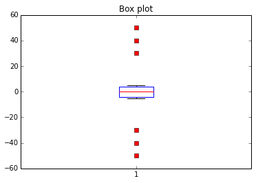

```python
%matplotlib inline
import matplotlib.pyplot as plt

x = [-50,-40,-30,-5,-4,-3,-2,-1,0,1,2,3,4,5,30,40,50]

fig = plt.figure()
plt.boxplot(x,
            notch=False, # box instead of notch shape
            sym='rs',    # red squares for outliers
            vert=True)   # vertical box aligmnent
t = plt.title('Box plot')
plt.show()
```

Likewise, for the second problem, the lower quartile is 1.5, the median is 4, and the upper quartile is 35. The fact that no datapoints are between 0 and the lower quartile minus 1.5 IQR's implies that the lower whisker ends at 0.

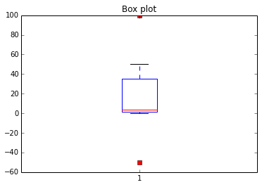

```python
x = [-50,0,1,2,3,4,5,30,40,50,100]

fig = plt.figure()
plt.boxplot(x,
            notch=False, # box instead of notch shape
            sym='rs',    # red squares for outliers
            vert=True)   # vertical box aligmnent
t = plt.title('Box plot')
plt.show()
```

#### Problem 4

The number of different ways to end at $-4$, $-2$, $0$, $2$, and $4$ remains the same as in Problem 1, but the likelihoods have changed. In particular, the likelihood of $k$ of the steps being backward becomes $$ \binom{4}{k} \left(\frac{1}{3}\right)^k \left(\frac{2}{3}\right)^{4-k} $$ since there are $\binom{4}{k}$ different ways that this can occur and each occurence involves $k$ backward steps and $4-k$ forward steps.

The expectation can be computed as $$ E[W_4] = \frac{1}{81}*(-4) + \frac{8}{81}*(-2) + \frac{24}{81}*(0) + \frac{32}{81}*(2) + \frac{16}{81}*(4) = \frac{4}{3}, $$ while the variance is $$ \text{Var}[W_4] = E[(W_4-E[W_4])^2] = \frac{1}{81}*(-4-\frac{4}{3})^2 + \frac{8}{81}*(-2-\frac{4}{3})^2 + \frac{24}{81}*(0-\frac{4}{3})^2 + \frac{32}{81}*(2-\frac{4}{3})^2 + \frac{16}{81}*(4-\frac{4}{3})^2 = \frac{16^2+8*10^2+24*4^2+32*2^2+16*8^2}{729} = \frac{2592}{729} \approx 3.5556, $$

and the Mean Absolute Deviation is $$ \text{MAD}[W_4] = E[|W_4-E[W_4]|] = \frac{1}{81}*|-4-\frac{4}{3}| + \frac{8}{81}*|-2-\frac{4}{3}| + \frac{24}{81}*|0-\frac{4}{3}| + \frac{32}{81}*|2-\frac{4}{3}| + \frac{16}{81}*|4-\frac{4}{3}| = \frac{16+80+96+64+128}{243} \approx 1.580247. $$